# Generalization to MultiZebra

Do the GSM-Symbolic transfer findings hold on a structurally different task? We score **MultiZebra** (logic-grid “zebra” puzzles) per puzzle and fit the *same* model as GSM – including the `model:language` transfer variance component – so we can compare both the fixed effects and the transfer gap on the same footing.

**Scope.** The MultiZebra runs cover 6 models (Qwen3.5 4/9/27B, EuroLLM 1.7/9/22B, 2 families) and 5 languages – **da, de, en, is, nl, all Germanic and Latin-script**. So this tests whether the **resource** and **size** effects (and their interaction) generalize; it cannot test typology, fertility, or script, which barely vary in a Germanic-only set. Predictors are on a per-doubling (log2) scale, centred at ~32M Common Crawl pages and an 8B model, shared with the GSM fit. The three Qwen3.5 models are additionally run with reasoning on and off, giving within-base pairs that let us test whether the **reasoning** finding from GSM generalizes too (final section).

**Scoring.** `score_zebra.py` reproduces EuroEval’s cell-wise metric exactly (alexandrainst/zebra_puzzles `compute_cell_score`: per-object set intersection, case-sensitive, whitespace-stripped, objects matched by sorted key), with markdown `` ```json `` fences stripped before parsing. Validated against EuroEval’s official aggregate to a mean absolute difference of ~1.2 points. It emits one row per (model, language, puzzle) with the cell counts, giving a binomial outcome (correct cells / total cells) analogous to GSM’s correct/total.

```r
knitr::opts_chunk$set(warning = FALSE, message = TRUE)
library(dplyr)
library(lme4)
```

```r
library(ggplot2)

zebra_all <- read.csv("generalization-analysis/zebra_puzzle_scores.csv") %>%
  mutate(
    resource_c = (log10_resource - 7.5) * log2(10), # doublings of CC pages
    size_c     = log2(params_b) - 3,                 # doublings of params
    reasoning  = factor(reasoning, levels = c("off", "on"))
  ) %>%
  mutate(across(c(model, base_model, family, language, puzzle), as.factor))

# Truncation. The runs cap generation at 8k tokens, so reasoning-on models that
# exhaust the budget mid-thought return an empty prediction (33% of reasoning-on
# rows, ~0% otherwise). These are a budget artifact, not a capability signal -- and
# they hit English heavily too (37%), so counting them wrong would spuriously flatten
# the cross-lingual gap -- so we EXCLUDE them as the primary treatment. The Reasoning
# section reports count-as-wrong as a sensitivity floor. `truncated` flags them.
zebra_scored <- filter(zebra_all, truncated == 0)      # all models, truncated dropped
zebra <- zebra_scored                                  # main resource/size comparison

# Robustness cut: the reasoning-off runs never truncate (0% empty), so they give a
# resource/size estimate with no missing-data assumption at all -- and, unlike
# reasoning-on, their size slope is not flattened by reasoning substituting for scale.
zebra_off <- filter(zebra_all, reasoning == "off")
```

# By language

Cell accuracy and exact-solve rate both show the GSM pattern – English best, Icelandic (lowest resource) clearly worst. The 1024 puzzles are the same set across all languages, so a `(1 | puzzle)` matched design holds.

```r
zebra %>%
  group_by(language) %>%
  summarise(
    log10_resource = first(log10_resource),
    cell_accuracy  = sum(n_correct_cells) / sum(n_cells),
    solve_rate     = mean(solved),
    .groups = "drop"
  ) %>%
  arrange(desc(log10_resource))
```

```
## # A tibble: 5 × 4
##   language log10_resource cell_accuracy solve_rate
##   <fct>             <dbl>         <dbl>      <dbl>
## 1 eng                8.95         0.472      0.292
## 2 deu                8.11         0.372      0.242
## 3 nld                7.60         0.414      0.248
## 4 dan                7.06         0.370      0.224
## 5 isl                5.89         0.339      0.181
```

# Full model

```r
full <- glmer(
  cbind(n_correct_cells, n_cells - n_correct_cells) ~ resource_c * size_c + reasoning +
    (1 | model) + (1 | language) + (1 | puzzle) + (1 | model:language),
  data = zebra, family = binomial())

base <- glmer(
  cbind(n_correct_cells, n_cells - n_correct_cells) ~ size_c + reasoning +
    (1 | model) + (1 | language) + (1 | puzzle) + (1 | model:language),
  data = zebra, family = binomial())

summary(base)
```

```
## Generalized linear mixed model fit by maximum likelihood (Laplace
##   Approximation) [glmerMod]
##  Family: binomial  ( logit )
## Formula: cbind(n_correct_cells, n_cells - n_correct_cells) ~ size_c +
##     reasoning + (1 | model) + (1 | language) + (1 | puzzle) +
##     (1 | model:language)
##    Data: zebra
##
##       AIC       BIC    logLik -2*log(L)  df.resid
##  192635.7  192696.0  -96310.8  192621.7     40927
##
## Scaled residuals:
##      Min       1Q   Median       3Q      Max
## -10.5410  -1.2969  -0.2775   1.3579  25.1179
##
## Random effects:
##  Groups         Name        Variance Std.Dev.
##  puzzle         (Intercept) 0.1133   0.3366
##  model:language (Intercept) 0.2352   0.4850
##  model          (Intercept) 0.7436   0.8623
##  language       (Intercept) 0.0725   0.2693
## Number of obs: 40934, groups:
## puzzle, 1024; model:language, 45; model, 9; language, 5
##
## Fixed effects:
##             Estimate Std. Error z value Pr(>|z|)
## (Intercept)  -1.2516     0.3831  -3.267 0.001086 **
## size_c        0.3533     0.2323   1.521 0.128273
## reasoningon   2.3437     0.6314   3.712 0.000206 ***
## ---
## Signif. codes:  0 '***' 0.001 '**' 0.01 '*' 0.05 '.' 0.1 ' ' 1
##
## Correlation of Fixed Effects:
##             (Intr) size_c
## size_c      -0.067
## reasoningon -0.530 -0.121
```

```r
summary(full)
```

```
## Generalized linear mixed model fit by maximum likelihood (Laplace
##   Approximation) [glmerMod]
##  Family: binomial  ( logit )
## Formula: cbind(n_correct_cells, n_cells - n_correct_cells) ~ resource_c *
##     size_c + reasoning + (1 | model) + (1 | language) + (1 |
##     puzzle) + (1 | model:language)
##    Data: zebra
##
##       AIC       BIC    logLik -2*log(L)  df.resid
##  192633.7  192711.3  -96307.8  192615.7     40925
##
## Scaled residuals:
##      Min       1Q   Median       3Q      Max
## -10.5162  -1.2971  -0.2779   1.3576  25.1012
##
## Random effects:
##  Groups         Name        Variance Std.Dev.
##  puzzle         (Intercept) 0.11331  0.3366
##  model:language (Intercept) 0.21155  0.4600
##  model          (Intercept) 0.74011  0.8603
##  language       (Intercept) 0.02878  0.1697
## Number of obs: 40934, groups:
## puzzle, 1024; model:language, 45; model, 9; language, 5
##
## Fixed effects:
##                   Estimate Std. Error z value Pr(>|z|)
## (Intercept)       -1.25462    0.36692  -3.419 0.000628 ***
## resource_c         0.05167    0.03030   1.705 0.088178 .
## size_c             0.35085    0.22984   1.526 0.126891
## reasoningon        2.34315    0.62250   3.764 0.000167 ***
## resource_c:size_c  0.02947    0.01582   1.863 0.062440 .
## ---
## Signif. codes:  0 '***' 0.001 '**' 0.01 '*' 0.05 '.' 0.1 ' ' 1
##
## Correlation of Fixed Effects:
##             (Intr) rsrc_c size_c rsnngn
## resource_c  -0.005
## size_c      -0.076  0.001
## reasoningon -0.548  0.000 -0.111
## rsrc_c:sz_c  0.001 -0.121 -0.005 -0.001
```

The resource main effect is positive and marginal; **size is positive but not significant here**, which is a truncation/reasoning artifact, not an absence of a size effect. Two things depress it: reasoning-on truncation removes data size-dependently (small models truncate most), and reasoning substitutes for scale, flattening the size slope with thinking on (see Reasoning). On the truncation-free reasoning-off runs the size effect is clean and clearly significant:

```r
full_off <- glmer(
  cbind(n_correct_cells, n_cells - n_correct_cells) ~ resource_c * size_c +
    (1 | model) + (1 | language) + (1 | puzzle) + (1 | model:language),
  data = zebra_off, family = binomial())
summary(full_off)
```

```
## Generalized linear mixed model fit by maximum likelihood (Laplace
##   Approximation) [glmerMod]
##  Family: binomial  ( logit )
## Formula: cbind(n_correct_cells, n_cells - n_correct_cells) ~ resource_c *
##     size_c + (1 | model) + (1 | language) + (1 | puzzle) + (1 |
##     model:language)
##    Data: zebra_off
##
##       AIC       BIC    logLik -2*log(L)  df.resid
##  125846.4  125913.0  -62915.2  125830.4     30712
##
## Scaled residuals:
##     Min      1Q  Median      3Q     Max
## -5.3975 -1.2492 -0.3767  1.0121 25.4349
##
## Random effects:
##  Groups         Name        Variance Std.Dev.
##  puzzle         (Intercept) 0.12931  0.3596
##  model:language (Intercept) 0.30222  0.5497
##  model          (Intercept) 0.36345  0.6029
##  language       (Intercept) 0.02212  0.1487
## Number of obs: 30720, groups:
## puzzle, 1024; model:language, 30; model, 6; language, 5
##
## Fixed effects:
##                   Estimate Std. Error z value Pr(>|z|)
## (Intercept)       -1.29458    0.27117  -4.774 1.81e-06 ***
## resource_c         0.06228    0.03551   1.754 0.079469 .
## size_c             0.64957    0.19368   3.354 0.000797 ***
## resource_c:size_c  0.03007    0.02163   1.391 0.164303
## ---
## Signif. codes:  0 '***' 0.001 '**' 0.01 '*' 0.05 '.' 0.1 ' ' 1
##
## Correlation of Fixed Effects:
##             (Intr) rsrc_c size_c
## resource_c  -0.009
## size_c      -0.082  0.001
## rsrc_c:sz_c  0.001 -0.077 -0.009
```

```r
sd_ml <- function(m) attr(VarCorr(m)$`model:language`, "stddev")[[1]]
zebra_var <- data.frame(
  task = "MultiZebra",
  sd_ml_full = sd_ml(full),
  sd_ml_baseline = sd_ml(base),
  variance_explained = 1 - sd_ml(full)^2 / sd_ml(base)^2
)
zebra_var
```

```
##         task sd_ml_full sd_ml_baseline variance_explained
## 1 MultiZebra  0.4599506      0.4849843          0.1005708
```

# Comparison with GSM-Symbolic

`gsm_generalization_estimates.csv` and `gsm_generalization_variance.csv` come from `export_gsm_estimates.R`, which fits the identical structure on the GSM cells.

```r
gsm <- read.csv("../../artifacts/analysis/gsm_generalization_estimates.csv")

est <- function(fit, task) {
  co <- summary(fit)$coefficients
  data.frame(task = task, term = rownames(co), estimate = co[, "Estimate"],
             se = co[, "Std. Error"], p_value = co[, "Pr(>|z|)"])
}

comparison <- bind_rows(gsm,
                        est(full, "MultiZebra (all models)"),
                        est(full_off, "MultiZebra (reasoning-off)")) %>%
  filter(term %in% c("resource_c", "size_c", "resource_c:size_c", "reasoningon")) %>%
  mutate(term = recode(term,
                       resource_c = "resource (per doubling of CC pages)",
                       size_c = "size (per doubling of params)",
                       `resource_c:size_c` = "resource x size",
                       reasoningon = "reasoning (on vs off)"),
         term = factor(term, levels = c("resource x size", "size (per doubling of params)",
                                        "resource (per doubling of CC pages)",
                                        "reasoning (on vs off)")),
         sig = cut(p_value, c(-Inf, 0.001, 0.01, 0.05, Inf), labels = c("***", "**", "*", "ns")),
         p_value = signif(p_value, 2))
comparison
```

```
##                                              task
## ...1                                 GSM-Symbolic
## ...2                                 GSM-Symbolic
## ...3                                 GSM-Symbolic
## ...4                                 GSM-Symbolic
## resource_c...5            MultiZebra (all models)
## size_c...6                MultiZebra (all models)
## reasoningon               MultiZebra (all models)
## resource_c:size_c...8     MultiZebra (all models)
## resource_c...9         MultiZebra (reasoning-off)
## size_c...10            MultiZebra (reasoning-off)
## resource_c:size_c...11 MultiZebra (reasoning-off)
##                                                       term    estimate
## ...1                   resource (per doubling of CC pages)  0.22845845
## ...2                         size (per doubling of params)  0.98720706
## ...3                                 reasoning (on vs off)  1.23975923
## ...4                                       resource x size -0.03934818
## resource_c...5         resource (per doubling of CC pages)  0.05167064
## size_c...6                   size (per doubling of params)  0.35085121
## reasoningon                          reasoning (on vs off)  2.34315461
## resource_c:size_c...8                      resource x size  0.02947037
## resource_c...9         resource (per doubling of CC pages)  0.06228404
## size_c...10                  size (per doubling of params)  0.64957263
## resource_c:size_c...11                     resource x size  0.03007497
##                                 se p_value sig
## ...1                   0.048651382 2.7e-06 ***
## ...2                   0.143031749 5.1e-12 ***
## ...3                   0.567211527 2.9e-02   *
## ...4                   0.005090007 1.1e-14 ***
## resource_c...5         0.030303779 8.8e-02  ns
## size_c...6             0.229843827 1.3e-01  ns
## reasoningon            0.622498371 1.7e-04 ***
## resource_c:size_c...8  0.015817398 6.2e-02  ns
## resource_c...9         0.035514288 7.9e-02  ns
## size_c...10            0.193675149 8.0e-04 ***
## resource_c:size_c...11 0.021625119 1.6e-01  ns
```

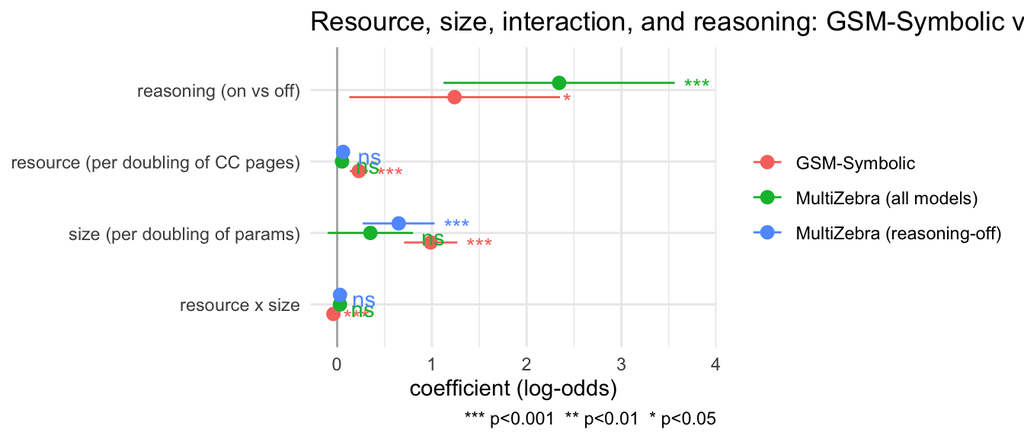

```r
dodge <- position_dodge(width = 0.4)
comparison %>%
  ggplot(aes(estimate, term, colour = task)) +
  geom_vline(xintercept = 0, colour = "grey70") +
  geom_pointrange(aes(xmin = estimate - 1.96 * se, xmax = estimate + 1.96 * se), position = dodge) +
  geom_text(aes(x = estimate + 1.96 * se, label = sig), position = dodge,
            hjust = -0.35, vjust = 0.75, show.legend = FALSE) +
  scale_x_continuous(expand = expansion(mult = c(0.05, 0.12))) +
  labs(x = "coefficient (log-odds)", y = NULL, colour = NULL,
       title = "Resource, size, interaction, and reasoning: GSM-Symbolic vs MultiZebra",
       caption = "*** p<0.001  ** p<0.01  * p<0.05") +
  theme_minimal()
```

The **transfer variance component** and how much of it resource explains:

```r
bind_rows(read.csv("../../artifacts/analysis/gsm_generalization_variance.csv"), zebra_var) %>%
  mutate(across(where(is.numeric), ~round(., 3)))
```

```
##           task sd_ml_full sd_ml_baseline variance_explained
## 1 GSM-Symbolic      0.494          0.555              0.208
## 2   MultiZebra      0.460          0.485              0.101
```

# What generalizes

- **Reasoning helps on both tasks**: +1.2 (GSM) vs +2.3 (MultiZebra) log-odds, significant on both, and larger on the logic puzzles – reasoning is a bigger lever on MultiZebra than on arithmetic. (These pooled coefficients are between-config on GSM and truncation-inflated on zebra; the clean within-base analysis is the Reasoning section.)
- **Size generalizes**: ~0.99 (GSM) vs **0.65 (MultiZebra, reasoning-off)** log-odds per doubling of parameters, both highly significant (p < 0.001) – larger models improve at a broadly similar rate on logic puzzles as on arithmetic, and size dominates resource in both. The all-models fit hides this (0.35, ns) only because reasoning-on truncation removes small-model data and reasoning flattens the size slope (see below); on the truncation-free runs the effect is clean.
- **The resource main effect generalizes directionally**: same sign, ~0.23 (GSM) vs ~0.05 (MultiZebra), and marginal on zebra (p ~ 0.09). The smaller, weaker estimate is what a Germanic-only set predicts – the resource range among the mid languages is narrow and the effect leans on Icelandic – so it is consistent with GSM, just underpowered.
- **The resource x size interaction does not replicate**: strongly negative on GSM (-0.039, p < 1e-13: larger models depend less on resource) but near zero and non-significant on MultiZebra (+0.03). Almost certainly a power problem – a product term needs joint variation in resource *and* size, and 6 models across 2 families gives very little – rather than a real difference.
- **The transfer gap itself is a similar size on both tasks**: `sd(model:language)` is 0.49 (GSM) vs 0.46 (all models) / 0.55 (reasoning-off) on the log-odds scale, so how much a model’s performance swings across languages beyond its overall level is comparable. Resource explains less of it on MultiZebra (~10% vs 21%), again consistent with the narrow Germanic resource range.

**Summary.** Reasoning, the size effect, and the magnitude of the cross-lingual transfer gap generalize to a structurally different task; the resource effect generalizes in direction; the interaction and the language-feature detail (typology, fertility, script) are untestable in a Germanic-only, 6-model set. The Reasoning section develops the first finding within base model: reasoning helps enormously and narrows the gap. A stronger test of the rest needs non-Germanic languages and more model families in the MultiZebra runs.

# Reasoning

The three Qwen3.5 models are run with thinking on and off, giving within-base pairs – so, as on GSM, we can ask whether reasoning helps and whether it narrows the cross-lingual gap. Its effect on puzzle-solving is large: the exact-solve rate roughly triples with thinking on (Qwen3.5-9B 10% -> 45%, 27B 20% -> 57%).

As a within-base fixed effect – identified against the reasoning-off runs, with `(1 | family/base_model)` holding the base model constant – reasoning is by far the largest term in the model:

```r
reasoning_fit <- glmer(
  cbind(n_correct_cells, n_cells - n_correct_cells) ~
    resource_c + size_c + reasoning +
    (1 | family / base_model) + (1 | language) + (1 | puzzle) + (1 | model:language),
  data = zebra_scored, family = binomial())
```

```
## boundary (singular) fit: see help('isSingular')
```

```r
summary(reasoning_fit)
```

```
## Generalized linear mixed model fit by maximum likelihood (Laplace
##   Approximation) [glmerMod]
##  Family: binomial  ( logit )
## Formula: cbind(n_correct_cells, n_cells - n_correct_cells) ~ resource_c +
##     size_c + reasoning + (1 | family/base_model) + (1 | language) +
##     (1 | puzzle) + (1 | model:language)
##    Data: zebra_scored
##
##       AIC       BIC    logLik -2*log(L)  df.resid
##  192641.2  192718.8  -96311.6  192623.2     40925
##
## Scaled residuals:
##      Min       1Q   Median       3Q      Max
## -10.4754  -1.2964  -0.2769   1.3575  25.1748
##
## Random effects:
##  Groups            Name        Variance  Std.Dev.
##  puzzle            (Intercept) 1.133e-01 3.366e-01
##  model:language    (Intercept) 3.238e-01 5.691e-01
##  base_model:family (Intercept) 6.662e-01 8.162e-01
##  language          (Intercept) 1.666e-02 1.291e-01
##  family            (Intercept) 1.706e-10 1.306e-05
## Number of obs: 40934, groups:
## puzzle, 1024; model:language, 45; base_model:family, 6; language, 5; family, 2
##
## Fixed effects:
##             Estimate Std. Error z value Pr(>|z|)
## (Intercept) -1.27816    0.34770  -3.676 0.000237 ***
## resource_c   0.05845    0.03018   1.937 0.052775 .
## size_c       0.54032    0.25069   2.155 0.031137 *
## reasoningon  2.11005    0.20493  10.297  < 2e-16 ***
## ---
## Signif. codes:  0 '***' 0.001 '**' 0.01 '*' 0.05 '.' 0.1 ' ' 1
##
## Correlation of Fixed Effects:
##             (Intr) rsrc_c size_c
## resource_c  -0.006
## size_c      -0.083  0.000
## reasoningon -0.137  0.000 -0.032
## optimizer (Nelder_Mead) convergence code: 0 (OK)
## boundary (singular) fit: see help('isSingular')
```

Its point magnitude is treatment-sensitive, though: truncation falls entirely on the reasoning-on side, so excluding it is a one-sided selection that lifts reasoning-on (the count-as-wrong floor puts the coefficient near +0.7 rather than +2.1). The direction is not in doubt – reasoning is the dominant effect – but we read the substance off the observed solve rates above and the gap below, not off this coefficient.

Does it narrow the cross-lingual gap? We read that off the English-to-target gap directly, as on GSM (a `reasoning x resource` interaction is a non-significant, truncation-sensitive null on this Germanic set, so we do not lean on it). Because reasoning-on can exhaust the 8k budget, we show both truncation treatments – the primary exclude, and count-as-wrong as the conservative floor:

```r
gap_table <- function(data) {
  paired <- semi_join(data,
    data %>% distinct(base_model, reasoning) %>% count(base_model) %>% filter(n == 2),
    by = "base_model")
  acc <- paired %>%
    group_by(reasoning, language) %>%
    summarise(acc = sum(n_correct_cells) / sum(n_cells), .groups = "drop") %>%
    mutate(logit = qlogis(acc))
  eng <- acc %>% filter(language == "eng") %>% select(reasoning, e_acc = acc, e_logit = logit)
  acc %>% filter(language != "eng") %>% left_join(eng, by = "reasoning") %>%
    group_by(reasoning) %>%
    summarise(mean_cell_acc    = mean(acc),
              gap_points       = mean(e_acc - acc),
              error_odds_ratio = mean(exp(e_logit - logit)), .groups = "drop")
}
bind_rows(
  cbind(treatment = "exclude-truncated (primary)",  gap_table(zebra_scored)),
  cbind(treatment = "count-as-wrong (sensitivity)", gap_table(zebra_all))
) %>% mutate(across(where(is.numeric), ~round(., 3)))
```

```
##                      treatment reasoning mean_cell_acc gap_points
## 1  exclude-truncated (primary)       off         0.287      0.135
## 2  exclude-truncated (primary)        on         0.692      0.083
## 3 count-as-wrong (sensitivity)       off         0.287      0.135
## 4 count-as-wrong (sensitivity)        on         0.468      0.018
##   error_odds_ratio
## 1            1.855
## 2            1.543
## 3            1.855
## 4            1.101
```

Reasoning narrows the cross-lingual gap on MultiZebra, robustly in either treatment: the English-to-target error odds-ratio falls from 1.85x (thinking off) to 1.54x (primary), or as far as 1.10x if truncations count as wrong. This mirrors GSM, where reasoning cut the same odds-ratio from ~2.9x to ~2.1x. So the reasoning finding generalizes – enabling reasoning both raises accuracy sharply and shrinks the relative English advantage across the Germanic target languages. As on GSM, the per-language `reasoning x resource` interaction is too underpowered to attribute the narrowing to resource specifically on the log-odds scale, so we report it as an aggregate gap.

**Caveat.** Only Qwen3.5 is run both ways, and truncated puzzles are ~1.8x harder than completed ones (measured against the reasoning-off runs), so the excluded estimate is a mild upper bound on capability while the count-as-wrong floor bounds it from below – both agree on the direction and the mirror of the GSM result.